# Final Results

PabloVigneron

2025-06-06

```r
# Importation des packages
library(tidyverse)
library(gridExtra)
#library(lubridate)
library(sf)
library(mapview)
library(maptiles)
library(tidyterra)
library(kableExtra)
#library(knitr)
library(janitor)
library(RVAideMemoire)
library(emmeans)
library(car)
library(MASS)
library(lme4)
library(MuMIn)
#library(stringr)
library(stringi)
library(terra)
library(ggspatial)
library(slippymath)
library(rosm)
library(writexl)
```

```r
# Importation des données - Secteur J25 : Petit Tregor
base_tregor <-
  readxl::read_xlsx(path = '../raw_data/export_suiviloutrelocal_telecharger_csv_2025_04_03_10h58m17.xlsx') %>%
  dplyr::select(
    id_dataset,
    code_secteur,
    code_site,
    nom_site,
    x_l93,
    y_l93,
    date_visite,
    observateurs,
    condition_prospection,
    nom_taxon,
    nom_complet_taxon,
    techn_observation,
    statut_observation,
    nb_ep_tot,
    nb_ep_w,
    nb_ep_dnf,
    nb_ep_df
  ) %>%
  mutate(
    annee = year(date_visite),
    mois = month(date_visite),
    jour = day(date_visite),
    nb_ep_w = abs(nb_ep_w),
    statut_observation = ifelse(str_detect(statut_observation, '^Pr'), yes = 'Présent', no = 'Absent')
  ) %>%
  filter(nom_complet_taxon =='Lutra lutra',
         !(id_dataset == 85 & code_secteur == "FR5300006"),
         code_secteur != "J401",
         !(annee == 2022)) %>%
  dplyr::distinct(code_site, annee, .keep_all = T)
#=> Suppression de la valeur de 2022 qui est une erreur de saisie
```

```r
#tab_1 <- tribble(~"Comparaison", ~"n",
#                 "Identiques", "32")

#knitr::kable((tab_1), booktabs = TRUE,
##caption = 'A test table.')
```

```r
# Importation avec data 2025 - Lieue de Greve

base_greve_raw <-
  readxl::read_xls(path = '../raw_data/Suivi loutre mars_25.xls',
                   skip = 1,
                   col_names = T)
```

```r
## Correction des données - Mise en forme - Secteur : Lieu Greve avec data 2025

base_greve <- base_greve_raw %>%
  janitor::clean_names() %>%
  dplyr::select(
    point_n,
    itineraire,
    x,
    y,
    commune,
    cours_deau,
    bilan_choix_du_site,
    epreinte_oct20,
    date_suivi_fev_mars21,
    marquage_suivi_fev_mars21,
    date_suivi_oct21,
    marquage_suivi_oct21,
    observateurs_suivi_oct21,
    date_suivi_mars22,
    marquage_suivi_mars22,
    observateurs_suivi_mars22,
    date_suivi_decembre22,
    marquage_suivi_decembre22,
    observateurs_suivi_decembre22,
    date_suivi_mars23,
    marquage_suivi_mars23,
    observateurs_suivi_mars23,
    date_suivi_octobre_24,
    marquage_suivi_octobre_24,
    observateurs_suivi_octobre_24,
    date_suivi_mars_25,
    marquage_suivi_mars_25,
    observateurs_suivi_mars_25
  ) %>%
  dplyr::rename(
    code_site = point_n,
    y = x,
    x = y,
    marquage_suivi_oct_20 = epreinte_oct20
  ) %>%
  dplyr::mutate(date_suivi_octobre_24 = as.Date(as.numeric(date_suivi_octobre_24), origin = "1899-12-30")) %>%
  dplyr::mutate(date_suivi_oct_20 = as.Date("2020-10-01")) %>%
  dplyr::mutate(across(
    c(
      date_suivi_fev_mars21,
      date_suivi_oct21,
      date_suivi_mars22,
      date_suivi_decembre22,
      date_suivi_mars23,
      date_suivi_oct_20,
      date_suivi_mars_25
    ),
    ~ as.POSIXct(.x)
  )) %>%
  mutate(across(starts_with("marquage_suivi_"), as.character)) %>%
  tidyr::pivot_longer(
    cols = c(
      date_suivi_oct_20,
      marquage_suivi_oct_20,
      date_suivi_fev_mars21,
      marquage_suivi_fev_mars21,
      date_suivi_oct21,
      marquage_suivi_oct21,
      observateurs_suivi_oct21,
      date_suivi_mars22,
      marquage_suivi_mars22,
      observateurs_suivi_mars22,
      date_suivi_decembre22,
      marquage_suivi_decembre22,
      observateurs_suivi_decembre22,
      date_suivi_mars23,
      marquage_suivi_mars23,
      observateurs_suivi_mars23,
      date_suivi_octobre_24,
      marquage_suivi_octobre_24,
      observateurs_suivi_octobre_24,
      date_suivi_mars_25,
      marquage_suivi_mars_25,
      observateurs_suivi_mars_25
    ),
    names_to = c(".value", "session"),
    names_pattern = "(date_suivi|marquage_suivi|observateurs_suivi)_(.*)"
  ) %>%
  rename(
    date_visite = date_suivi,
    statut_presence = marquage_suivi,
    observateurs = observateurs_suivi
  ) %>%
  dplyr::mutate(
    annee = year(date_visite),
    mois = month(date_visite),
    jour = day(date_visite),
    code_site = as.factor(code_site),
    statut_presence = case_when(
      tolower(statut_presence) == "oui" ~ 1,
      suppressWarnings(as.numeric(statut_presence)) >= 1 ~ 1,
      tolower(statut_presence) %in% c("non", "peut_etre") ~ 0,
      TRUE ~ 0
    ),
    statut_observation = ifelse(statut_presence == 1, "Présent", "Absent"),
    statut_presence = as.factor (statut_presence),
    jour = ifelse(jour == 1, NA, jour),
    annee = ifelse(annee == 2002, 2021, annee),
    y = str_replace_all(y, ",", ""),
    x = str_replace_all(x, " ", ""),
    passage = ifelse(mois <= 6, 1, 2),
    date_visite = ifelse(
      date_visite == as.Date("2002-02-24"),
      "2021-02-24",
      as.character(date_visite)
    ),
    observateurs_clean = observateurs %>%
      str_to_lower() %>%
      str_replace_all(" et ", "_") %>%
      str_replace_all("[[:space:]]+", "_") %>%
      str_replace_all("[^a-z0-9_]", "") %>%
      stri_trans_general("latin-ascii")
  ) %>%
  dplyr::mutate(observateurs_clean = as.factor(
    ifelse(
      observateurs_clean == "maxime_chapelle_romain_salaun",
      "maxime_chapelle_romain_salun",
      observateurs_clean
    )
  )) %>%
  dplyr::filter(!is.na(code_site), !is.na(itineraire))
```

```r
# Export jeu de donnée pour carte SIG
readr::write_csv(base_greve,
                    path = "../processed_data/base_Lieue_de_greve.csv"
                    )
```

```r
# Export jeu de donnée pour carte SIG
readr::write_csv(base_j25,
                    path = "../processed_data/base_Petit_tregor.csv"
                    )
```

**Sites d’études**

```r
# Représentation cartographique du secteur d'étude et des sites correspondants

sites_geo_1 <- base_greve %>%
  mutate(
    code_secteur = "J22",
    y = str_replace_all(y, ",", "."),
    x = str_replace_all(x, ",", "."),
    y = as.numeric(y),
    x = as.numeric(x)
  ) %>%
  filter(!is.na(x) & !is.na(y)) %>%
  rename(nom_site = commune) %>%
  dplyr::select(nom_site, code_site, code_secteur, statut_observation, annee, x, y) %>%
  st_as_sf(coords = c("x", "y"), crs = 4326) %>%
  st_transform(2154)

sites_geo_2 <- base_tregor %>%
  filter(code_secteur == "J25") %>%
  dplyr::select(nom_site:y_l93, code_site, code_secteur, statut_observation, annee) %>%
  st_as_sf(coords = c("x_l93", "y_l93"), crs = 2154)

common_cols <- dplyr::intersect(names(sites_geo_1), names(sites_geo_2))

sites_geo <- bind_rows(
  sites_geo_1[, common_cols],
  sites_geo_2[, common_cols]
)

mapview(sites_geo, zcol = "code_secteur", col.regions = c("darkseagreen3", "indianred1"))
```

[interactive chart not shown]

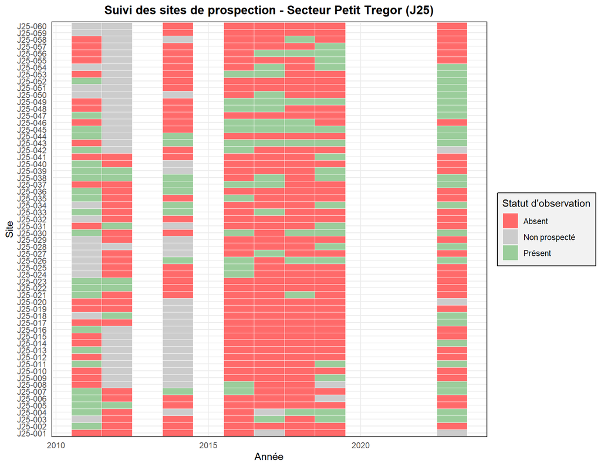

Figure 1: Statut d’observation des sites prospectée en fonction des années

[figure not shown]

Figure 2: Statut d’observation des sites prospectée en fonction des années, 1er passage (printemps)

```r
base_j25 <- base_j25 %>%
  mutate(annee = year(date_visite))

all_combos <- expand_grid(code_site = unique(base_j25$code_site),
                          annee = unique(base_j25$annee))

obs_complete <- all_combos %>%
  left_join(base_j25 %>% dplyr::select(code_site, annee, statut_observation),
            by = c("code_site", "annee")) %>%
  mutate(
    statut_final = case_when(
      statut_observation == "Présent" ~ "Présent",
      statut_observation == "Absent" ~ "Absent",
      TRUE ~ "Non prospecté"
    )
  )

ggplot(obs_complete, aes(x = annee, y = code_site, fill = statut_final)) +
  geom_tile(color = "white", linewidth = 0.3) +
  scale_fill_manual(
    values = c(
      "Présent" = "darkseagreen3",
      "Absent" = "indianred1",
      "Non prospecté" = "grey80"
    )
  ) +
  labs(x = "Année",
       y = "Site",
       title = "Suivi des sites de prospection - Secteur Petit Tregor (J25)",
       fill = "Statut d'observation") +
  theme_minimal() +
  theme(
    plot.title = element_text(hjust = 0.5, face = "bold"),
    panel.border = element_rect(color = "black", fill = NA),
    legend.background = element_rect(fill = "grey95", color = "black")
  )
```

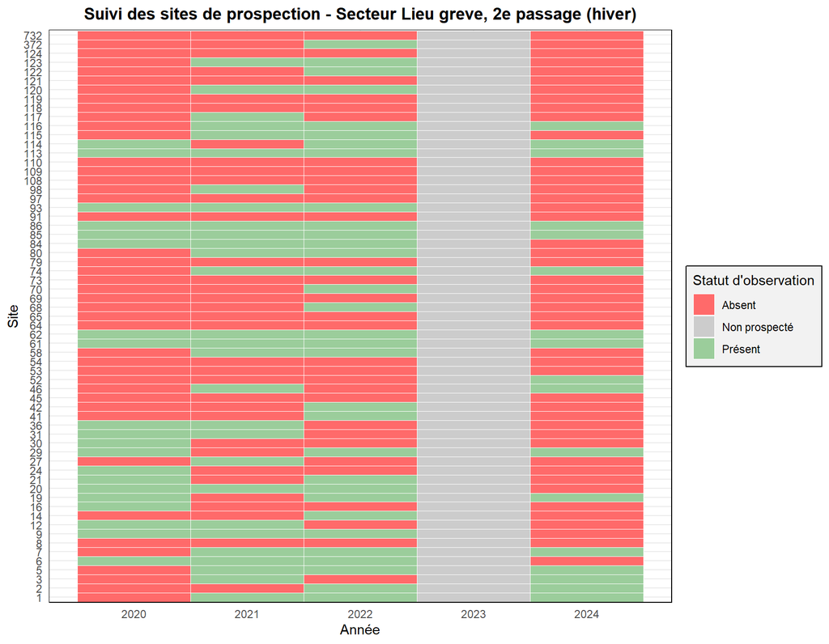

Figure 3: Statut d’observation des sites prospectée en fonction des années, 2e passage (hiver)

```r
base_greve_winter <- base_greve %>%
  dplyr::filter(passage == 2)

annees_completes <- 2020:2024

all_combos <- expand_grid(
  code_site = unique(base_greve_winter$code_site),
  annee = annees_completes
)

obs_complete <- all_combos %>%
  left_join(
    base_greve_winter %>%
      dplyr::select(code_site, annee, statut_observation),
    by = c("code_site", "annee")
  ) %>%
  dplyr::mutate(
    statut_final = case_when(
      statut_observation == "Présent" ~ "Présent",
      statut_observation == "Absent" ~ "Absent",
      TRUE ~ "Non prospecté"
    )
  )

ggplot(obs_complete, aes(x = annee, y = code_site, fill = statut_final)) +
  geom_tile(color = "white", linewidth = 0.3) +
  scale_fill_manual(values = c(
    "Présent" = "darkseagreen3",
    "Absent" = "indianred1",
    "Non prospecté" = "grey80"
  )) +
  labs(x = "Année",
       y = "Site",
       title = "Suivi des sites de prospection - Secteur Lieu greve, 2e passage (hiver)",
       fill = "Statut d'observation") +
  theme_minimal() +
  theme(
    plot.title = element_text(hjust = 0.5, face = "bold"),
    panel.border = element_rect(color = "black", fill = NA),
    legend.background = element_rect(fill = "grey95", color = "black")
  )
```

# 1 RESULTATS

## 1.1 Modelisation

### 1.1.1 Secteur Petit Trégor

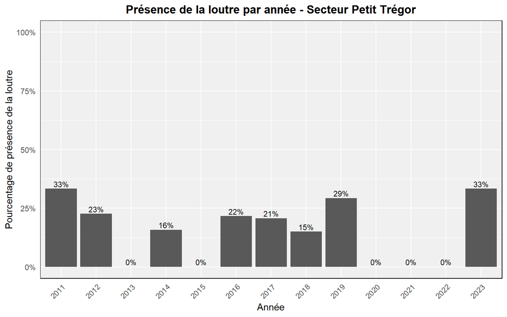

Figure 4: Pourcentages de présence de la loutre en fonction des passages et des années

| Modèle | Fonction de lien | Estimate coefficient, annee | p values |
| --- | --- | --- | --- |
| statut_presence ~ annee + (1 \| code_site) | Logit | 0.02853 | 0.411 NS |
| statut_presence ~ annee + (1 \| code_site) | Probit | 0.013919 | 1.39e-09 *** |
| statut_presence ~ annee + (1 \| code_site) | cauchit | 8.067e-02 | <2e-16 *** |

```r
annees_completes <- 2011:2023

combi <- expand_grid(annee = annees_completes)

resume <- base_j25 %>%
  group_by(annee) %>%
  summarise(
    n_obs = n(),
    n_presences = sum(statut_presence == "1"),
    pc_presences = n_presences / n_obs,
    .groups = "drop"
  )

resume_complet <- combi %>%
  left_join(resume, by = "annee") %>%
  replace_na(list(
    n_obs = 0,
    n_presences = 0,
    pc_presences = 0
  )) %>%
  dplyr::mutate(annee = factor(annee, levels = annees_completes))

ggplot(resume_complet,
       aes(x = factor(annee), y = pc_presences)) +
  geom_bar(stat = "identity", position = position_dodge()) +
  geom_text(
    aes(label = scales::percent(pc_presences, accuracy = 1)),
    position = position_dodge(width = 0.9),
    vjust = -0.3,
    size = 3
  )+
  labs(x = "Année",
       y = "Pourcentage de présence de la loutre",
       fill = "Passage",
       title = "Présence de la loutre par année - Secteur Petit Trégor") +
  scale_y_continuous(labels = scales::percent_format(accuracy = 1),
                     limits = c(0, 1)) +
  theme_minimal() +
  theme(
    plot.title = element_text(hjust = 0.5, face = "bold"),
    panel.border = element_rect(
      color = "black",
      fill = NA,
      linewidth = 0.5
    ),
    axis.text.x = element_text(angle = 45, hjust = 1),
    panel.background = element_rect(fill = "grey94", color = "white"),
    plot.background = element_rect(fill = "white", color = NA),
    legend.background = element_rect(fill = "grey94", color = "black"),
    panel.grid.major = element_line(color = "white"),
    panel.grid.minor = element_line(color = "white")
  )
```

```r
base_j25_year_numeric <-  base_j25 %>%
  mutate(annee = as.numeric(annee),
         statut_presence = as.factor(statut_presence))
```

```r
mod3.0 <- glmer(statut_presence~annee+(1|code_site), family=binomial(link = "logit"), data = base_j25_year_numeric)
```

```r
#plotresid(mod3.0)
```

```r
#summary(mod3.0)
```

```r
mod3.1 <- glmer(statut_presence~annee+(1|code_site), family=binomial(link = "probit"), data = base_j25_year_numeric)
```

```r
#plotresid(mod3.1)
```

```r
#summary(mod3.1)
```

```r
mod3.2 <- glmer(statut_presence~annee+(1|code_site), family=binomial(link = "cauchit"), data = base_j25_year_numeric)
```

```r
#plotresid(mod3.2)
```

```r
#summary(mod3.2)
```

## 1.2 Modelisation

### 1.2.1 Secteur de la Lieue de grève

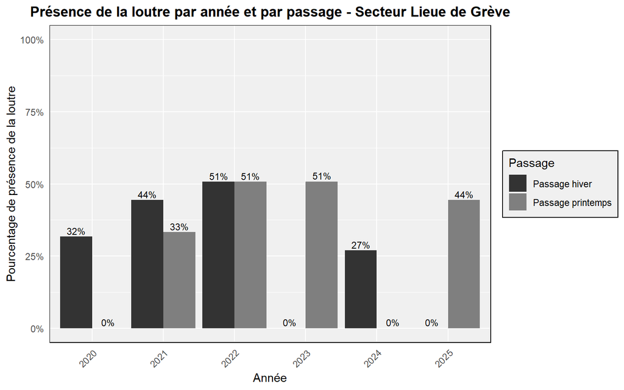

Figure 5: Pourcentages de présence de la loutre en fonction des passages et des années

| Modèle | Fonction de lien | Estimate coefficient, annee | p values |
| --- | --- | --- | --- |
| statut_presence ~ annee + passage + (1 \| code_site) | Logit | 0.001335 | 0.3071 NS |
| statut_presence ~ annee + passage + (1 \| code_site) | Probit | 0.002219 | 0.5060 NS |
| statut_presence ~ annee + passage + (1 \| code_site) | cauchit | -0.02917 | 0.7001 NS |

```r
base_greve_passage <- base_greve %>%
  mutate(
    passage_label = ifelse(mois <= 6, "Passage printemps", "Passage hiver"),
    passage_label = factor(passage_label, levels = c("Passage printemps", "Passage hiver"))
  )


annees <- sort(unique(base_greve_passage$annee))
passages <- c("Passage printemps", "Passage hiver")
combi <- expand_grid(annee = annees, passage_label = passages)

resume <- base_greve_passage %>%
  group_by(annee, passage_label) %>%
  summarise(
    n_obs = n(),
    n_presences = sum(statut_presence == '1'),
    pc_presences = n_presences / n_obs,
    .groups = "drop"
  )

resume_complet <- combi %>%
  left_join(resume, by = c("annee", "passage_label")) %>%
  replace_na(list(
    n_obs = 0,
    n_presences = 0,
    pc_presences = 0
  ))
ggplot(resume_complet, aes(x = factor(annee), y = pc_presences, fill = passage_label)) +
  geom_bar(stat = "identity", position = position_dodge()) +
  geom_text(aes(label = scales::percent(pc_presences, accuracy = 1)),
            position = position_dodge(width = 0.9), vjust = -0.3, size = 3) +
  scale_fill_manual(
    values = c("Passage printemps" = "gray50", "Passage hiver" = "grey20")
  ) +
  labs(
    x = "Année",
    y = "Pourcentage de présence de la loutre",
    fill = "Passage",
    title = "Présence de la loutre par année et par passage - Secteur Lieue de Grève"
  ) +
  scale_y_continuous(labels = scales::percent_format(accuracy = 1), limits = c(0, 1)) +
  theme_minimal()+
  theme(
    plot.title = element_text(hjust = 0.5, face = "bold"),
    panel.border = element_rect(
      color = "black",
      fill = NA,
      linewidth = 0.5
    ),
    axis.text.x = element_text(angle = 45, hjust = 1),
    panel.background = element_rect(fill = "grey94", color = "white"),
    plot.background = element_rect(fill = "white", color = NA),
    legend.background = element_rect(fill = "grey94",color = "black"),
    panel.grid.major = element_line(color = "white"),
    panel.grid.minor = element_line(color = "white")
  )
```

```r
greve_year_factor_season <- base_greve%>%
  mutate(annee = as.numeric(annee),
         passage = as.factor(passage))
```

```r
mod5.0<- glmer(statut_presence~annee + passage + (1|code_site), family=binomial(link = "logit"), data = greve_year_factor_season)
```

```r
#plotresid(mod5.0)
```

```r
#summary(mod5.0)
```

```r
mod5.1<- glmer(statut_presence~annee + passage + (1|code_site), family=binomial(link = "probit"), data = greve_year_factor_season)
```

```r
#plotresid(mod5.1)
```

```r
#summary(mod5.1)
```

```r
mod5.2<- glmer(statut_presence~annee + passage + (1|code_site), family=binomial(link = "cauchit"), data = greve_year_factor_season)
```

```r
#plotresid(mod5.2)
```

```r
#summary(mod5.2)
```

```r
mod6.0<- glmer(statut_presence~annee + (1|code_site), family=binomial(link = "logit"), data = greve_year_factor_season)
```

```r
#plotresid(mod6.0)
```

```r
#summary(mod6.0)
```

```r
#mod6.1<- glmer(statut_presence~annee + (1|code_site), family=binomial(link = "probit"), data = greve_year_factor_season)
```

```r
#plotresid(mod6.1)
```

```r
#summary(mod6.1)
```

```r
mod6.2<- glmer(statut_presence~annee + (1|code_site), family=binomial(link = "cauchit"), data = greve_year_factor_season)
```

```r
#plotresid(mod6.2)
```

```r
#summary(mod6.2)
```

| Modèle | Fonction de lien | Estimate coefficient, annee | p values |
| --- | --- | --- | --- |
| statut_presence ~ annee + (1 \| code_site) | Logit | 0.042909 | <2e-16 *** |
| statut_presence ~ annee + (1 \| code_site) | cauchit | 0.01462 | 0.836 NS |

## 1.3 Simulation (Secteur Petit Trégor)

```r
library(tidyverse)
library(lme4)
load(file = "../processed_data/base_j25_year_numeric.rda")
source(file = "../R/simulation.R")
```

```r
set.seed(123)
```

```r
df <- base_j25_year_numeric %>%
  mutate(code_site = as.factor(code_site),
         statut_presence = as.integer(statut_presence) - 1,
         date_annee = lubridate::yday(date_visite))
```

```r
df_rand <- df %>%
  group_by(code_site) %>%
  mutate(annee_perm = gtools::permute(annee)) %>%
  ungroup() %>%
  mutate(annee_perm_index = annee_perm - min(annee_perm))
```

```r
mod <- glmer(statut_presence~annee_perm+(1|code_site), family=binomial(link = "logit"), data = df_rand)
#summary(mod)

pente_obs <- summary(mod)$coefficients[2,1]
```

```r
df_trend1 <- df_rand %>%
  ajouter_presences_annuelles(n_pres_suppl_par_an = 1) #%>%
  # cbind(statut_presence_rand = df_rand$statut_presence) %>%
  # mutate(presence_ajoutee = (statut_presence_rand != statut_presence_sim))
```

# 2 Test : le modèle permet-il de détecter la tendance ?

On fait tourner le modèle avec `statut_presence_sim` en variable dépendante et la variable `annee_perm` en prédicteur, avec l’effet aléatoire du `code_site`.

## 2.1 Test initial

```r
mod_tend1 <- glmer(statut_presence_sim ~
                     annee_perm +
                     (1|code_site),
                   family=binomial(link = "logit"),
                   data = df_trend1)
summary(mod_tend1)
```

```
## Generalized linear mixed model fit by maximum likelihood (Laplace
##   Approximation) [glmerMod]
##  Family: binomial  ( logit )
## Formula: statut_presence_sim ~ annee_perm + (1 | code_site)
##    Data: df_trend1
##
##      AIC      BIC   logLik deviance df.resid
##    513.7    525.8   -253.9    507.7      404
##
## Scaled residuals:
##     Min      1Q  Median      3Q     Max
## -1.4232 -0.6662 -0.5253  1.0032  2.2171
##
## Random effects:
##  Groups    Name        Variance Std.Dev.
##  code_site (Intercept) 0.5593   0.7478
## Number of obs: 407, groups:  code_site, 60
##
## Fixed effects:
##               Estimate Std. Error z value Pr(>|z|)
## (Intercept) -1.645e+02  1.956e+00  -84.13   <2e-16 ***
## annee_perm   8.121e-02  9.736e-04   83.41   <2e-16 ***
## ---
## Signif. codes:  0 '***' 0.001 '**' 0.01 '*' 0.05 '.' 0.1 ' ' 1
##
## Correlation of Fixed Effects:
##            (Intr)
## annee_perm -0.997
## optimizer (Nelder_Mead) convergence code: 0 (OK)
## Model failed to converge with max|grad| = 0.121856 (tol = 0.002, component 1)
## Model is nearly unidentifiable: very large eigenvalue
##  - Rescale variables?
## Model is nearly unidentifiable: large eigenvalue ratio
##  - Rescale variables?
```

Avec p<1E-16 et une pente positive on a bien détecté la tendance à l’augmentation du signal au fil des années.

## 2.2 Test avec une tendance plus faible

```r
set.seed(124)
df_trend1 <- df_rand %>%
  ajouter_presences_annuelles(n_pres_suppl_par_an = 0.1)

mod_trend1 <- glmer(statut_presence_sim ~
                     annee_perm +
                     (1|code_site),
                   family=binomial(link = "logit"),
                   data = df_trend1)
summary(mod_trend1)
```

```
## Generalized linear mixed model fit by maximum likelihood (Laplace
##   Approximation) [glmerMod]
##  Family: binomial  ( logit )
## Formula: statut_presence_sim ~ annee_perm + (1 | code_site)
##    Data: df_trend1
##
##      AIC      BIC   logLik deviance df.resid
##    440.9    453.0   -217.5    434.9      404
##
## Scaled residuals:
##     Min      1Q  Median      3Q     Max
## -1.1949 -0.5090 -0.3726 -0.3383  2.3383
##
## Random effects:
##  Groups    Name        Variance Std.Dev.
##  code_site (Intercept) 0.9314   0.9651
## Number of obs: 407, groups:  code_site, 60
##
## Fixed effects:
##               Estimate Std. Error z value Pr(>|z|)
## (Intercept) -19.599419  69.731050  -0.281    0.779
## annee_perm    0.009035   0.034574   0.261    0.794
##
## Correlation of Fixed Effects:
##            (Intr)
## annee_perm -1.000
## optimizer (Nelder_Mead) convergence code: 0 (OK)
## unable to evaluate scaled gradient
## Model failed to converge: degenerate  Hessian with 1 negative eigenvalues
```

Tendance non détectée. Il faut dire qu’elle est très faible :

```r
table(df_trend1$annee_perm[df_trend1$statut_presence == 1])
```

```
##
## 2011 2012 2014 2016 2017 2018 2019 2023
##   11    8   10   11   16   14   14   14
```

```r
table(df_trend1$annee_perm[df_trend1$statut_presence_sim == 1])
```

```
##
## 2011 2012 2014 2016 2017 2018 2019 2023
##   11    8   10   11   16   14   14   15
```

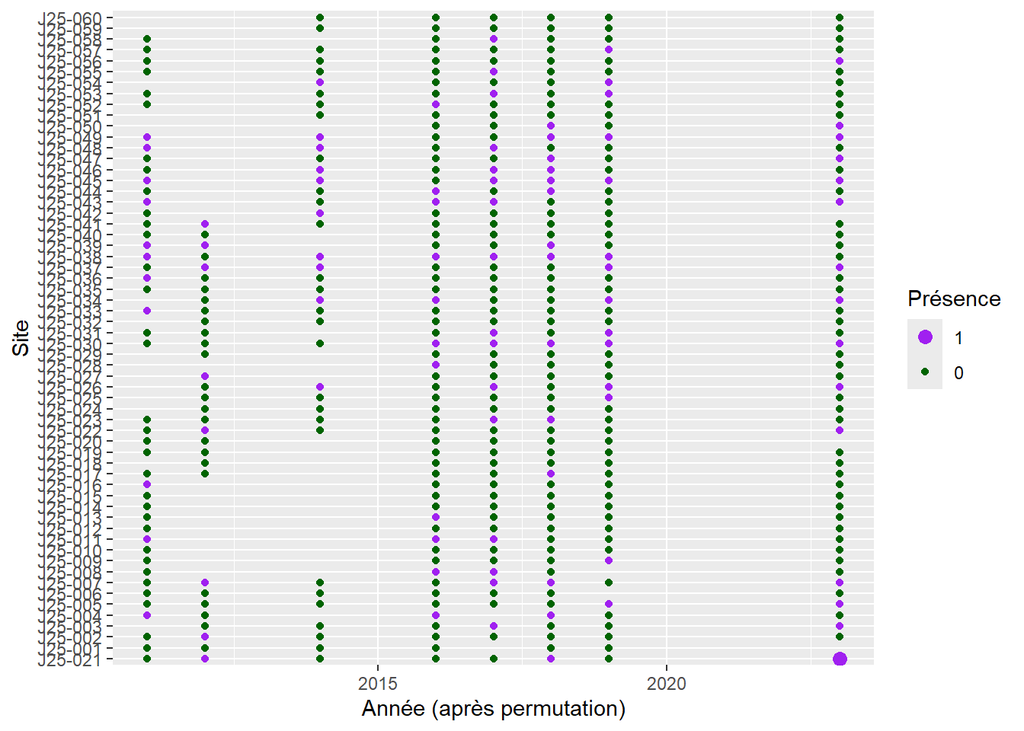

```r
my_point_plot(df_trend1)
```

## 2.3 Avec un peu plus de tendance

```r
set.seed(125)
df_trend1 <- df_rand %>%
  ajouter_presences_annuelles(n_pres_suppl_par_an = 0.2)

mod_trend1 <- glmer(statut_presence_sim ~
                      annee_perm +
                      (1|code_site),
                    family=binomial(link = "logit"),
                    data = df_trend1)
summary(mod_trend1)
```

```
## Generalized linear mixed model fit by maximum likelihood (Laplace
##   Approximation) [glmerMod]
##  Family: binomial  ( logit )
## Formula: statut_presence_sim ~ annee_perm + (1 | code_site)
##    Data: df_trend1
##
##      AIC      BIC   logLik deviance df.resid
##    455.3    467.3   -224.6    449.3      404
##
## Scaled residuals:
##     Min      1Q  Median      3Q     Max
## -1.1440 -0.5519 -0.4125  0.8539  2.3055
##
## Random effects:
##  Groups    Name        Variance Std.Dev.
##  code_site (Intercept) 0.7748   0.8802
## Number of obs: 407, groups:  code_site, 60
##
## Fixed effects:
##               Estimate Std. Error  z value Pr(>|z|)
## (Intercept) -3.913e+01  1.649e-03 -23731.7   <2e-16 ***
## annee_perm   1.877e-02  8.392e-05    223.7   <2e-16 ***
## ---
## Signif. codes:  0 '***' 0.001 '**' 0.01 '*' 0.05 '.' 0.1 ' ' 1
##
## Correlation of Fixed Effects:
##            (Intr)
## annee_perm -0.010
## optimizer (Nelder_Mead) convergence code: 0 (OK)
## Model failed to converge with max|grad| = 0.0438417 (tol = 0.002, component 1)
## Model is nearly unidentifiable: very large eigenvalue
##  - Rescale variables?
```

On a ici détection de la tendance, sans avoir ajouté énormément de présences :

```r
table(df_trend1$annee_perm[df_trend1$statut_presence == 1])
```

```
##
## 2011 2012 2014 2016 2017 2018 2019 2023
##   11    8   10   11   16   14   14   14
```

```r
table(df_trend1$annee_perm[df_trend1$statut_presence_sim == 1])
```

```
##
## 2011 2012 2014 2016 2017 2018 2019 2023
##   11    8   10   12   17   15   15   16
```

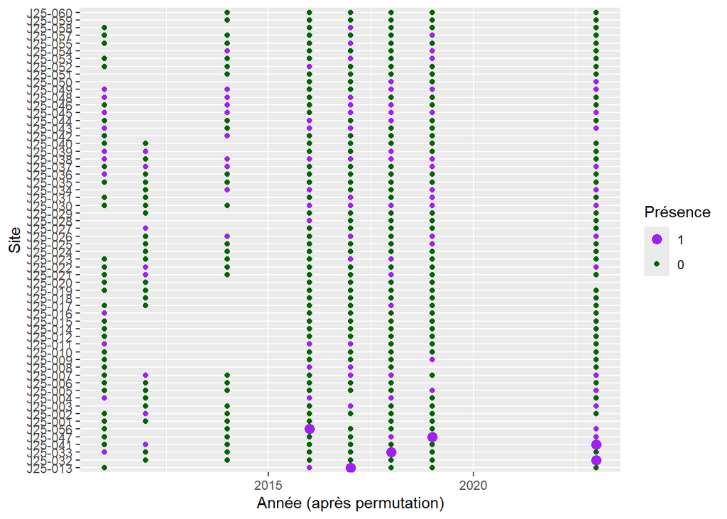

```r
my_point_plot(df_trend1)
```

# 3 Généralisation

Pour chacun des tests ci-dessous, on enchaîne 100 fois les opérations suivantes :

- Permutations des années pour gommer le signal
- Ajout de présences
- Calage du modèle
- Récupération de la pente associée à l’année et de la p-value associée
- Histogramme des pentes

## 3.1 En l’absence de tendance

On s’attend pour ce modèle “neutre” à ce que les pentes soient non significatives dans 95% des cas et que la distribution soit centrée sur zéro et symétrique.

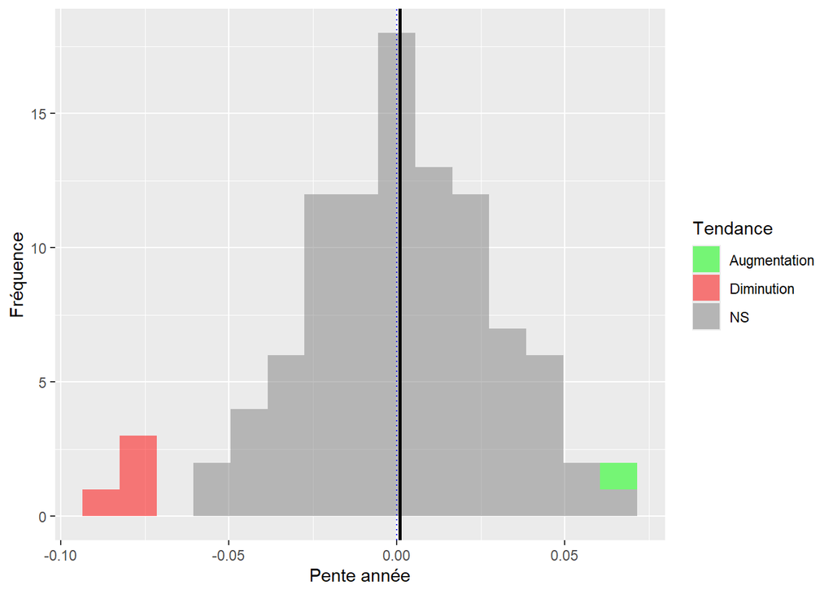

Figure 6: Histogramme des pentes (n=100) obtenues par le modèle après permutation des années. Les couleurs permettent de distinguer les pentes selon leur signe et leur significativité au seuil de 5%.

```r
set.seed(NULL)
test2 <- tester_tendance(df = df,
                         n_pres_suppl_par_an = 0,
                         n_permutations = 100)

my_histo(test2) +
  geom_vline(xintercept = pente_obs, col = "black", lwd = 1)
```

```r
pc_detec_aug_0 <- nrow(test2[test2$tendance == "Augmentation",]) / nrow(test2)
```

On va ensuite recommencer avec des tendances de plus en plus nettes, c’est-à-dire en rajoutant de plus en plus de présences chaque année.

## 3.2 Tendance faible

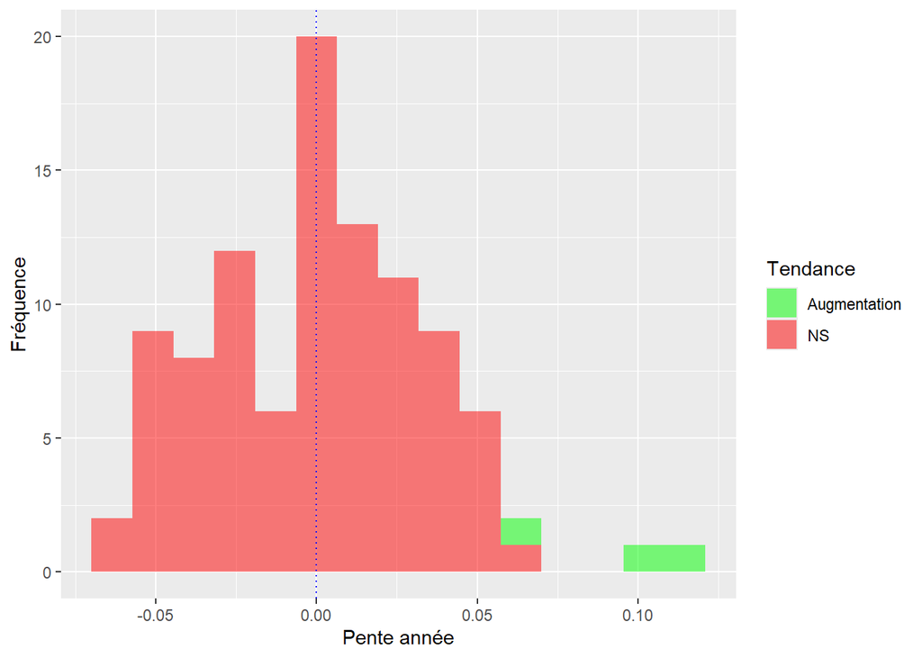

```r
test2 <- tester_tendance(df = df,
                         n_pres_suppl_par_an = 0.1,
                         n_permutations = 100)

my_histo(test2)
```

```r
pc_detec_aug_0.1 <- nrow(test2[test2$tendance == "Augmentation",]) / nrow(test2)
```

Pas vraiment de différence avec l’absence de tendance. Pas très surprenant car ça revient à ne rajouter qu’une présence en dernière année.

## 3.3 Tendance modérée

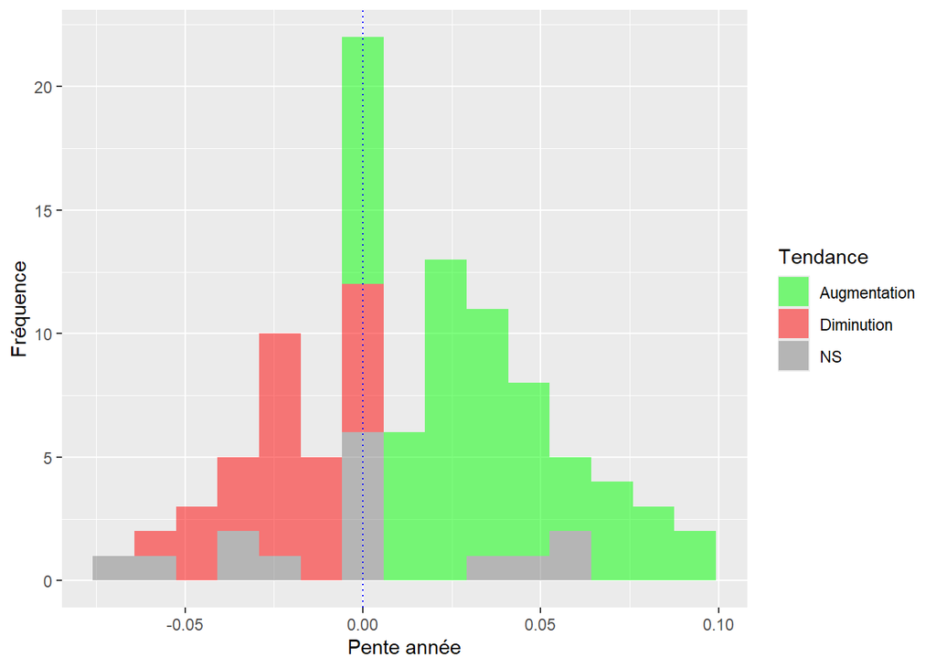

```r
test2 <- tester_tendance(df = df,
                         n_pres_suppl_par_an = 0.2,
                         n_permutations = 100)

my_histo(test2)
```

```r
pc_detec_aug_0.2 <- nrow(test2[test2$tendance == "Augmentation",]) / nrow(test2)
```

Là ça change. La plupart des pentes sont significatices. Bizarrement on en a plus de négatives qu’avec les jeu de données “neutres”.

## 3.4 Tendance forte

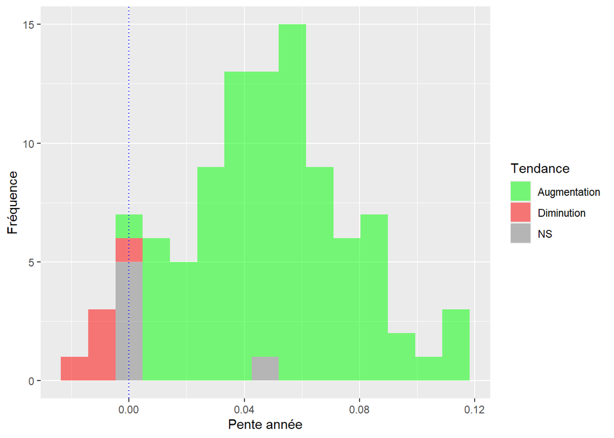

```r
test2 <- tester_tendance(df = df,
                         n_pres_suppl_par_an = 0.5,
                         n_permutations = 100)

my_histo(test2)
```

```r
pc_detec_aug_0.5 <- nrow(test2[test2$tendance == "Augmentation",]) / nrow(test2)
```

## 3.5 Tendance très forte

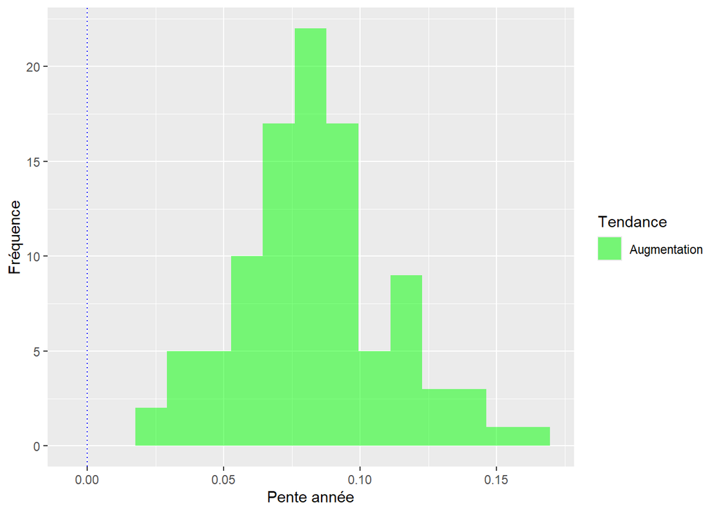

```r
test2 <- tester_tendance(df = df,
                         n_pres_suppl_par_an = 1,
                         n_permutations = 100)

my_histo(test2)
```

```r
pc_detec_aug_1 <- nrow(test2[test2$tendance == "Augmentation",]) / nrow(test2)
```

# 4 Synthèse

On calcule un taux de détection pour différentes valeurs de la tendance injectée. Pour limiter le temps de calcul on ne recommence pas pour les valeurs déjà calculées.

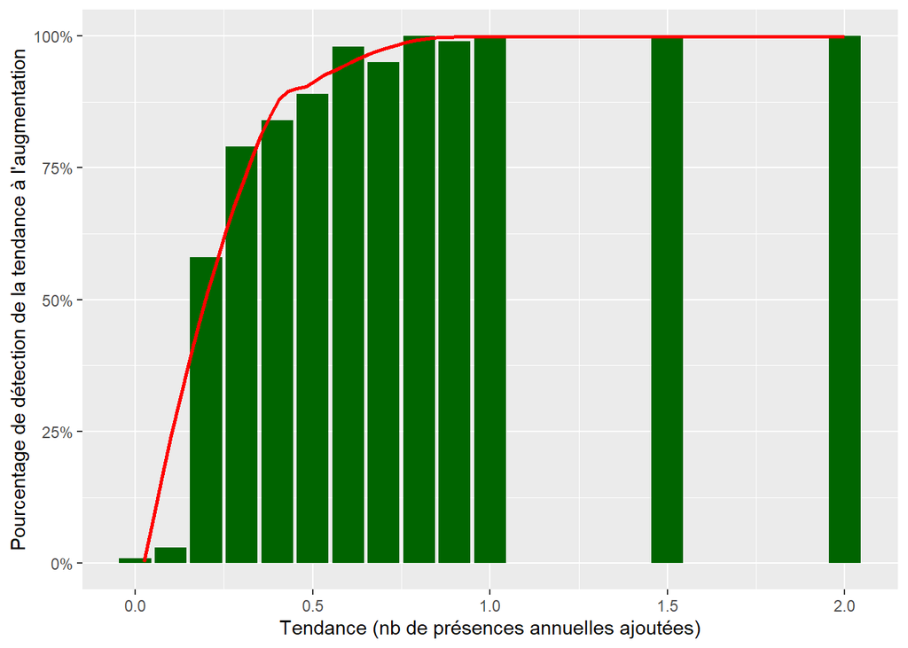

```r
tendances <- c(0.3, 0.4, 0.6, 0.7, 0.8, 0.9, 1.5, 2)

resultat <- map(
  .x = tendances,
  .f = get_pc_sig,
  df = df,
  n_permutations = 100
)

pc_detec_aug <- c(
  pc_detec_aug_0,
  pc_detec_aug_0.1,
  pc_detec_aug_0.2,
  resultat[1:2],
  pc_detec_aug_0.5,
  resultat[3:6],
  pc_detec_aug_1,
  resultat[7:8]
) %>%
  unlist()

tendance <- c(seq(0, 1, 0.1), 1.5, 2)

df_resume <- data.frame(tendance,
                        pc_detec_aug)

ggplot(data = df_resume,
       aes(x = tendance,
           y = pc_detec_aug)) +
  geom_bar(stat = "identity",
           fill = "darkgreen") +
  geom_smooth(col = "red", se = FALSE) +
  scale_y_continuous(limits = c(0, 1), labels = scales::percent) +
  labs(x = "Tendance (nb de présences annuelles ajoutées)",
       y = "Pourcentage de détection de la tendance à l'augmentation")
```